# Homework Four 4_Part 2

DACSS 603

Cynthia Hester  
April 18,2022

```r
project_data_path <- here("project_donation_data")
here(project_data_path)
```

```
[1] "C:/Users/Bud/Desktop/project_donation_data"
```

```r
#here::here()
```

# PART 2 (Final Project)

1.What is your research question for the final project?

2.What is your hypothesis (i.e. an answer to the research question) that you want to test?

3.Present some exploratory analysis. In particular:

a.Numerically summarize (e.g. with the summary() function) the variables of interest (the outcome, the explanatory variable, the control variables).

b.Plot the relationships between key variables. You can do this any way you want, but one straightforward way of doing this would be with the pairs() function or other scatter plots / box plots. Interpret what you see.

### Introduction

Professional sports leagues in the United States have been at the intersection of politics since the inception of sports leagues. It is therefore not surprising that owners of these sports leagues donate to political parties.

For this project, I draw from the Five-Thirty-Eight database of professional sports league ownership,2016-2020 in 2 year election cycles.Data is in CSV file format.

The data contains every confirmed partisan political contribution from team owners and commissioners in the NFL, NBA, WNBA, NHL, MLB and NASCAR from 2016-2020.

### Project Proposal

1. What is your research question for the final project?

*What were the political donation patterns of major sport team owners in the United States,during election cycles 2016-2020?*

2. What is your hypothesis (i.e. an answer to the research question) that you want to test?

*My hypothesis is that professional sports team franchise owners are more likely to donate to Republican candidates, issues and causes.*

3. Present some exploratory analysis. In particular:

**a**.Numerically summarize (e.g. with the summary() function) the variables of interest (the outcome, the explanatory variable, the control variables).

First csv data is imported

```r
library (readr)

urlfile="https://raw.githubusercontent.com/fivethirtyeight/data/master/sports-political-donations/sports-political-donations.csv"

project_donation_data<-read_csv(url(urlfile))
```

**To gain insight I will first explore the data set.**

```r
head(project_donation_data,10)      #first 10 rows of data set
```

```
# A tibble: 10 x 7
   Owner       Team      League Recipient Amount `Election Year` Party
   <chr>       <chr>     <chr>  <chr>     <chr>            <dbl> <chr>
 1 Adam Silver Commissi~ NBA    WRIGHT 2~ $4,000            2016 Demo~
 2 Adam Silver Commissi~ NBA    BIDEN FO~ $2,800            2020 Demo~
 3 Adam Silver Commissi~ NBA    CORY 2020 $2,700            2020 Demo~
 4 Adam Silver Commissi~ NBA    Kamala H~ $2,700            2020 Demo~
 5 Adam Silver Commissi~ NBA    Win The ~ $2,700            2020 Demo~
 6 Adam Silver Commissi~ NBA    KOHL FOR~ $2,000            2018 Demo~
 7 Adam Silver Commissi~ NBA    BETO FOR~ $1,000            2018 Demo~
 8 Adam Silver Commissi~ NBA    MONTANAN~ $1,000            2018 Demo~
 9 Adam Silver Commissi~ NBA    SERVE AM~ $1,000            2018 Demo~
10 Adam Silver Commissi~ NBA    ADAM SCH~ $1,000            2020 Demo~
```

```r
tail(project_donation_data,10)      #last 10 rows of data set
```

```
# A tibble: 10 x 7
   Owner     Team        League Recipient Amount `Election Year` Party
   <chr>     <chr>       <chr>  <chr>     <chr>            <dbl> <chr>
 1 Zygi Wilf Minnesota ~ NFL    AMY FOR ~ $5,600            2020 Demo~
 2 Zygi Wilf Minnesota ~ NFL    KLOBUCHA~ $5,400            2018 Demo~
 3 Zygi Wilf Minnesota ~ NFL    Gridiron~ $5,000            2020 Bipa~
 4 Zygi Wilf Minnesota ~ NFL    MCCOLLUM~ $2,700            2016 Demo~
 5 Zygi Wilf Minnesota ~ NFL    TERRI BO~ $2,700            2016 Demo~
 6 Zygi Wilf Minnesota ~ NFL    ANGIE CR~ $2,700            2018 Demo~
 7 Zygi Wilf Minnesota ~ NFL    DEAN PHI~ $2,700            2018 Demo~
 8 Zygi Wilf Minnesota ~ NFL    MENENDEZ~ $2,700            2018 Demo~
 9 Zygi Wilf Minnesota ~ NFL    TINA SMI~ $2,700            2018 Demo~
10 Zygi Wilf Minnesota ~ NFL    TOM MALI~ $2,700            2018 Demo~
```

```r
summary(project_donation_data)    #provides look at structure of data
```

```
    Owner               Team              League
 Length:2798        Length:2798        Length:2798
 Class :character   Class :character   Class :character
 Mode  :character   Mode  :character   Mode  :character



  Recipient            Amount          Election Year
 Length:2798        Length:2798        Min.   :2016
 Class :character   Class :character   1st Qu.:2016
 Mode  :character   Mode  :character   Median :2018
                                       Mean   :2018
                                       3rd Qu.:2020
                                       Max.   :2020
    Party
 Length:2798
 Class :character
 Mode  :character
```

```r
glimpse(project_donation_data)
```

```
Rows: 2,798
Columns: 7
$ Owner           <chr> "Adam Silver", "Adam Silver", "Adam Silver",~
$ Team            <chr> "Commissioner", "Commissioner", "Commissione~
$ League          <chr> "NBA", "NBA", "NBA", "NBA", "NBA", "NBA", "N~
$ Recipient       <chr> "WRIGHT 2016", "BIDEN FOR PRESIDENT", "CORY ~
$ Amount          <chr> "$4,000", "$2,800", "$2,700", "$2,700", "$2,~
$ `Election Year` <dbl> 2016, 2020, 2020, 2020, 2020, 2018, 2018, 20~
$ Party           <chr> "Democrat", "Democrat", "Democrat", "Democra~
```

Checking for missing data

```r
#view(project_donation_data)
#names(project_donation_data)    #names of data set variables

project_donation_data %>%
is.na() %>%
 sum()
```

```
[1] 0
```

I use the skimr() function to glean any additional insight into data set.

```r
skim(project_donation_data)  #provides insight into data set
```

Table 1: Data summary

| Name | project_donation_data |
| --- | --- |
| Number of rows | 2798 |
| Number of columns | 7 |
| _______________________ |  |
| Column type frequency: |  |
| character | 6 |
| numeric | 1 |
| ________________________ |  |
| Group variables | None |

**Variable type: character**

| skim_variable | n_missing | complete_rate | min | max | empty | n_unique | whitespace |
| --- | --- | --- | --- | --- | --- | --- | --- |
| Owner | 0 | 1 | 9 | 43 | 0 | 158 | 0 |
| Team | 0 | 1 | 9 | 59 | 0 | 115 | 0 |
| League | 0 | 1 | 3 | 14 | 0 | 16 | 0 |
| Recipient | 0 | 1 | 3 | 96 | 0 | 1274 | 0 |
| Amount | 0 | 1 | 3 | 10 | 0 | 244 | 0 |
| Party | 0 | 1 | 3 | 33 | 0 | 7 | 0 |

**Variable type: numeric**

| skim_variable | n_missing | complete_rate | mean | sd | p0 | p25 | p50 | p75 | p100 | hist |
| --- | --- | --- | --- | --- | --- | --- | --- | --- | --- | --- |
| Election Year | 0 | 1 | 2017.93 | 1.6 | 2016 | 2016 | 2018 | 2020 | 2020 | ▇▁▇▁▇ |

For easier readability and more insight into the data, it is converted to tabular format.

```r
library(DT)
datatable(data = project_donation_data,
          rownames = FALSE,
          filter ="top",
          options = list(autoWidth = TRUE))
```

| Owner | Team | League | Recipient | Amount | Election Year | Party |
| --- | --- | --- | --- | --- | --- | --- |
| Adam Silver | Commissioner | NBA | WRIGHT 2016 | $4,000 | 2016 | Democrat |
| Adam Silver | Commissioner | NBA | BIDEN FOR PRESIDENT | $2,800 | 2020 | Democrat |
| Adam Silver | Commissioner | NBA | CORY 2020 | $2,700 | 2020 | Democrat |
| Adam Silver | Commissioner | NBA | Kamala Harris for the People | $2,700 | 2020 | Democrat |
| Adam Silver | Commissioner | NBA | Win The Era PAC | $2,700 | 2020 | Democrat |
| Adam Silver | Commissioner | NBA | KOHL FOR CONGRESS | $2,000 | 2018 | Democrat |
| Adam Silver | Commissioner | NBA | BETO FOR TEXAS | $1,000 | 2018 | Democrat |
| Adam Silver | Commissioner | NBA | MONTANANS FOR TESTER | $1,000 | 2018 | Democrat |
| Adam Silver | Commissioner | NBA | SERVE AMERICA PAC | $1,000 | 2018 | Democrat |
| Adam Silver | Commissioner | NBA | ADAM SCHLEIFER FOR CONGRESS | $1,000 | 2020 | Democrat |

[output cut: 2788 more lines]

**Variables of Interest**

```r
colnames(project_donation_data)       #variable names
```

```
[1] "Owner"         "Team"          "League"        "Recipient"
[5] "Amount"        "Election Year" "Party"
```

Here I create a new object *donation_owner* and then check for which team owners donated to political parties most frequently

```r
#shows what owners donated most frequently to political affiliations.
donation_owner<-(sort(table(project_donation_data$Owner),decreasing = TRUE))
head(donation_owner,10)
```

```
                 Charles Johnson                     Micky Arison
                             213                              178
                     John Rogers                        Dan DeVos
                             149                              116
Jody Allen (Paul G. Allen Trust)           Jimmy and Susan Haslam
                             108                              102
                    Ken Kendrick                  Jerry Reinsdorf
                              86                               78
                   Herbert Simon                  Stephen M. Ross
                              68                               65
```

```r
#donation_owner %>%
  kable(head(donation_owner,n = 10)) %>%
  kable_classic(full_width=F,html_font = "Cambria4")
```

| Var1 | Freq |
| --- | --- |
| Charles Johnson | 213 |
| Micky Arison | 178 |
| John Rogers | 149 |
| Dan DeVos | 116 |
| Jody Allen (Paul G. Allen Trust) | 108 |
| Jimmy and Susan Haslam | 102 |
| Ken Kendrick | 86 |
| Jerry Reinsdorf | 78 |
| Herbert Simon | 68 |
| Stephen M. Ross | 65 |

Here I create a new object *donation_league* check for frequency of individual league donations.

```r
donation_league<-(sort(table(project_donation_data$League),decreasing = TRUE))
head(donation_league,10)     #displays which leagues received donations most often
```

```
      MLB       NBA       NFL       NHL      WNBA NBA, WNBA  NBA, NFL
      746       462       444       329       274       118       109
 NBA, NHL  NBA, MLB    NASCAR
      109        84        79
```

```r
#donation_owner %>%

  kable(head(donation_league,n = 5)) %>%
  kable_classic(full_width=F,html_font = "Cambria4")
```

| Var1 | Freq |
| --- | --- |
| MLB | 746 |
| NBA | 462 |
| NFL | 444 |
| NHL | 329 |
| WNBA | 274 |

Here a new object *donation_party* checks for which political party received the most donations.

```r
donation_party<-(sort(table(project_donation_data$Party),decreasing = TRUE))
head(donation_party,3)
```

```
Republican   Democrat Bipartisan
      1625        921        195
```

```r
#donation_owner %>%
  kable(head(donation_party)) %>%
  kable_classic(full_width=F,html_font = "Cambria4") %>%
  scroll_box(width = "100%",height = "400px")
```

| Var1 | Freq |
| --- | --- |
| Republican | 1625 |
| Democrat | 921 |
| Bipartisan | 195 |
| Bipartisan, but mostly Republican | 40 |
| N/A | 9 |
| Bipartisan, but mostly Democratic | 5 |

**b**. Plot the relationships between key variables. You can do this any way you want, but one straightforward way of doing this would be with the pairs() function or other scatter plots / box plots. Interpret what you see.

Here I use a bar plot to show the relationship between donations and sports leagues.

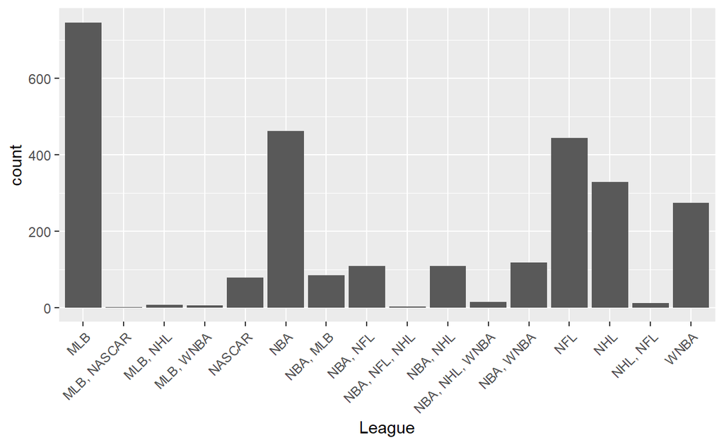

```r
ggplot(data = project_donation_data) +
   #theme(axis.text.x = element_text(vjust=1,angle=90))
   # theme(axis.text.x = element_text(angle = 90))
  stat_count(mapping = aes(x = League))+
theme(axis.text.x = element_text(angle = 45, hjust = 1))
```

Here I use a bar plot to show the relationship between political parties and donations.

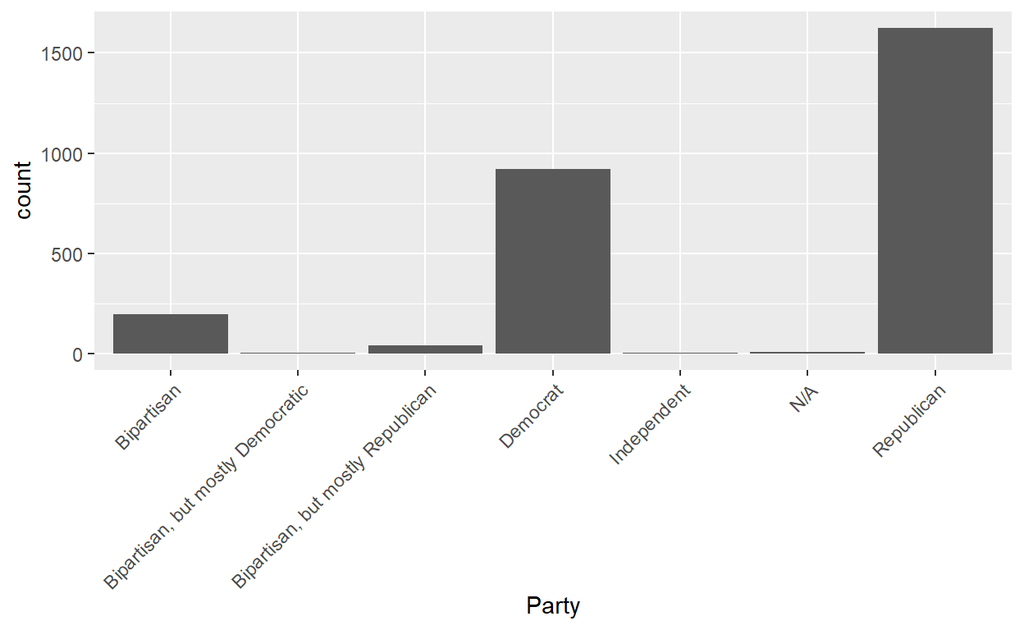

```r
ggplot(data = project_donation_data) +
   #theme(axis.text.x = element_text(vjust=1,angle=90))
   # theme(axis.text.x = element_text(angle = 90))
  stat_count(mapping = aes(x = Party))+
theme(axis.text.x = element_text(angle = 45, hjust = 1))
```

Here we see the Republican party received more donations from sports owners with the democratic party coming in a distant second.

**Debug**

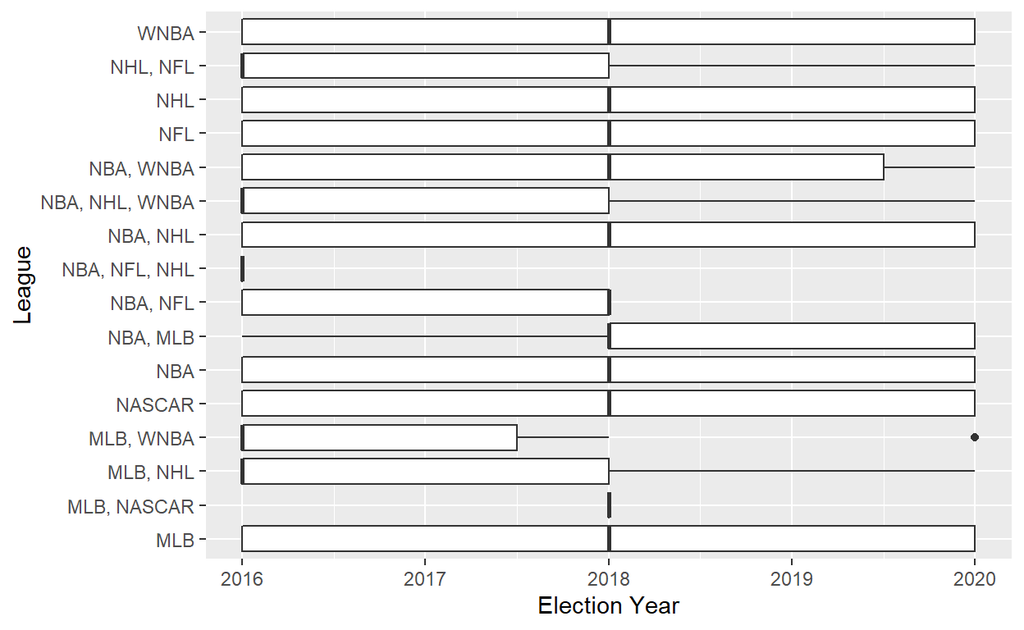

```r
ggplot(data = project_donation_data,
        aes(x=`Election Year`,y=League))+

geom_boxplot()
```